# Minería de Datos - Taller Clase 9

Cristian Harvey Ardila Bolívar

# Dataset del enunciado

```r
set.seed(2025)

n <- 400

estudiantes <- tibble(
  id         = 1:n,
  programa   = sample(
    c("Estadística", "Sistemas", "Economía", "Matemáticas"),
    n,
    replace = TRUE,
    prob = c(.3, .3, .25, .15)
  ),
  semestre   = sample(1:10, n, replace = TRUE),
  sexo       = sample(c("Mujer", "Hombre"), n, replace = TRUE),
  nota_final = round(rnorm(n, mean = 3.5, sd = 0.7), 1) |>
    pmin(5) |>
    pmax(0),
  horas_sem  = round(rnorm(n, mean = 18, sd = 5)),
  beca       = sample(c("Sí", "No"), n, replace = TRUE, prob = c(.3, .7))
)

head(estudiantes)
```

```
## # A tibble: 6 × 7
##      id programa semestre sexo   nota_final horas_sem beca
##   <int> <chr>       <int> <chr>       <dbl>     <dbl> <chr>
## 1     1 Economía       10 Hombre        2.7        15 No
## 2     2 Sistemas        1 Hombre        3.8        18 No
## 3     3 Sistemas        6 Hombre        3.8        28 No
## 4     4 Sistemas        6 Hombre        3.3        25 No
## 5     5 Economía        8 Mujer         3.9        12 No
## 6     6 Sistemas        2 Mujer         3.2        18 No
```

# 1 Ejercicio 1. Normalidad de notas

```r
normalidad_programa <- estudiantes |>
  group_by(programa) |>
  summarise(
    W = as.numeric(shapiro.test(nota_final)$statistic),
    p_valor = shapiro.test(nota_final)$p.value,
    .groups = "drop"
  ) |>
  mutate(
    rechaza_normalidad = if_else(
      p_valor < 0.05,
      "Sí",
      "No"
    )
  ) |>
  arrange(p_valor)

programas_rechazo <- normalidad_programa |>
  filter(p_valor < 0.05)

programa_menor_p <- normalidad_programa |>
  slice_min(p_valor, n = 1, with_ties = FALSE) |>
  pull(programa)

normalidad_programa
```

```
## # A tibble: 4 × 4
##   programa        W p_valor rechaza_normalidad
##   <chr>       <dbl>   <dbl> <chr>
## 1 Matemáticas 0.973   0.133 No
## 2 Sistemas    0.986   0.281 No
## 3 Estadística 0.991   0.601 No
## 4 Economía    0.991   0.733 No
```

```r
programas_rechazo
```

```
## # A tibble: 0 × 4
## # ℹ 4 variables: programa <chr>, W <dbl>, p_valor <dbl>,
## #   rechaza_normalidad <chr>
```

```r
programa_menor_p
```

```
## [1] "Matemáticas"
```

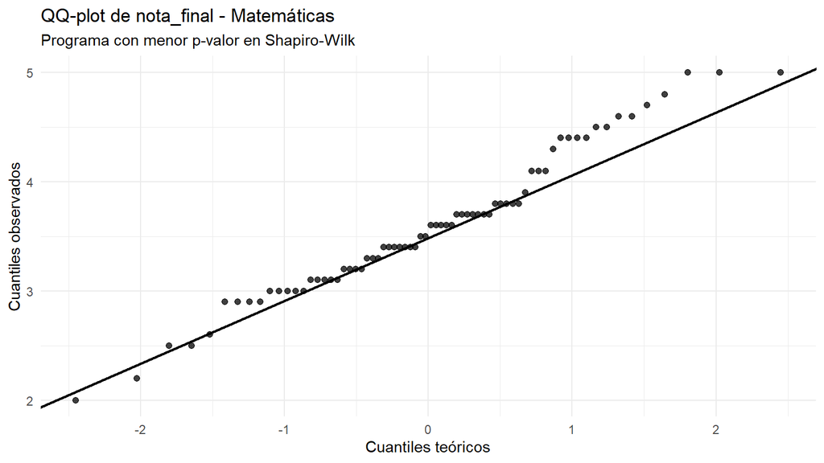

```r
datos_qq <- estudiantes |>
  filter(programa == programa_menor_p)

grafico_qq <- ggplot(datos_qq, aes(sample = nota_final)) +
  stat_qq(alpha = 0.75, size = 1.8) +
  stat_qq_line(linewidth = 0.8) +
  labs(
    title = paste("QQ-plot de nota_final -", programa_menor_p),
    subtitle = "Programa con menor p-valor en Shapiro-Wilk",
    x = "Cuantiles teóricos",
    y = "Cuantiles observados"
  ) +
  theme_minimal(base_size = 11)

grafico_qq
```

## 1.1 Comentarios

**1. ¿En qué programas se rechaza normalidad con** $\alpha = 0.05$?

No se rechaza normalidad en ninguna prueba, porque todos los p-valores son mayores que 0.05. Por tanto, no hay evidencia estadística suficiente para rechazar que las notas siguen una distribución aproximadamente normal dentro de cada programa.

**2. Construir el QQ-plot para el programa con el p-valor más bajo.**

El programa con menor p-valor es Matemáticas. Por eso el QQ-plot se construye usando las notas finales de ese programa.

**3. ¿Qué patrón se observa en las colas?**

En el QQ-plot de Matemáticas no se observa una desviación suficientemente fuerte como para rechazar normalidad al 5%. Hay pequeñas separaciones visuales en uno de los extremos, pero no son suficientes para contradecir el resultado de Shapiro-Wilk.

**4. Si la distribución no es normal, ¿qué implicaciones tiene para pruebas posteriores?**

Si una distribución no fuera normal, las pruebas paramétricas podrían perder validez porque no se cumplirían los supuestos distribucionales que justifican el cálculo de sus estadísticos. En ese caso, convendría usar herramientas robustas o pruebas no paramétricas.

# 2 Ejercicio 2. Estadísticos robustos y sesgo

```r
estadisticos_robustos <- estudiantes |>
  group_by(programa) |>
  summarise(
    media = mean(nota_final),
    mediana = median(nota_final),
    media_recortada = mean(nota_final, trim = 0.1),
    mad = mad(nota_final),
    cv = sd(nota_final) / mean(nota_final),
    asimetria = (mean(nota_final) - median(nota_final)) / sd(nota_final),
    .groups = "drop"
  ) |>
  mutate(
    discrepancia_media = abs(media - media_recortada),
    direccion_sesgo = case_when(
      asimetria > 0 ~ "Sesgo a la derecha",
      asimetria < 0 ~ "Sesgo a la izquierda",
      TRUE ~ "Sin sesgo apreciable"
    )
  ) |>
  arrange(desc(discrepancia_media))

programa_mayor_discrepancia <- estadisticos_robustos |>
  slice_max(discrepancia_media, n = 1, with_ties = FALSE) |>
  select(programa, media, media_recortada, discrepancia_media)

sesgo_por_programa <- estadisticos_robustos |>
  select(programa, asimetria, direccion_sesgo)

estadisticos_robustos
```

```
## # A tibble: 4 × 9
##   programa    media mediana media_recortada   mad    cv asimetria
##   <chr>       <dbl>   <dbl>           <dbl> <dbl> <dbl>     <dbl>
## 1 Matemáticas  3.59    3.55            3.57 0.667 0.185   0.0559
## 2 Sistemas     3.45    3.4             3.46 0.741 0.210   0.0695
## 3 Economía     3.50    3.5             3.50 0.741 0.204  -0.00420
## 4 Estadística  3.50    3.5             3.51 0.593 0.188   0.00509
## # ℹ 2 more variables: discrepancia_media <dbl>, direccion_sesgo <chr>
```

```r
programa_mayor_discrepancia
```

```
## # A tibble: 1 × 4
##   programa    media media_recortada discrepancia_media
##   <chr>       <dbl>           <dbl>              <dbl>
## 1 Matemáticas  3.59            3.57             0.0193
```

```r
sesgo_por_programa
```

```
## # A tibble: 4 × 3
##   programa    asimetria direccion_sesgo
##   <chr>           <dbl> <chr>
## 1 Matemáticas   0.0559  Sesgo a la derecha
## 2 Sistemas      0.0695  Sesgo a la derecha
## 3 Economía     -0.00420 Sesgo a la izquierda
## 4 Estadística   0.00509 Sesgo a la derecha
```

## 2.1 Comentarios

**1. ¿Qué programa muestra mayor discrepancia entre media y media recortada?**

El programa con mayor discrepancia entre media y media recortada es Matemáticas.

**2. ¿Qué indica esa discrepancia?**

Esa discrepancia indica que las colas de la distribución de los datos están afectando la media. En otras palabras, la media usual puede estar siendo más sensible a valores alejados del centro que la media recortada.

**3. Interpretar el coeficiente de asimetría de Pearson.**

El coeficiente de asimetría de Pearson compara la media con la mediana en unidades de desviación estándar. Si el valor es positivo, la distribución presenta sesgo a la derecha. Si el valor es negativo, presenta sesgo a la izquierda.

**4. ¿En qué dirección sesga cada distribución?**

La dirección del sesgo para cada programa queda resumida en la tabla `sesgo_por_programa`. Allí se observa si cada programa presenta sesgo a la derecha o a la izquierda.

**5. ¿Cuándo se preferiría reportar MAD en lugar de desviación estándar?**

Se preferiría reportar MAD cuando hay valores atípicos, asimetría o falta de normalidad. La MAD es más robusta porque se basa en la mediana y se altera menos por observaciones extremas.

# 3 Ejercicio 3. Valores atípicos

```r
detectar_outliers <- function(x) {
  q1  <- quantile(x, 0.25)
  q3  <- quantile(x, 0.75)
  iqr <- q3 - q1
  z   <- (x - mean(x)) / sd(x)

  tibble(
    valor = x,
    outlier_iqr = x < (q1 - 1.5 * iqr) | x > (q3 + 1.5 * iqr),
    outlier_z = abs(z) > 3
  )
}

outliers_estudiantes <- estudiantes |>
  group_by(programa) |>
  mutate(
    q1 = quantile(nota_final, 0.25),
    q3 = quantile(nota_final, 0.75),
    iqr = q3 - q1,
    z = (nota_final - mean(nota_final)) / sd(nota_final),
    outlier_iqr = nota_final < (q1 - 1.5 * iqr) |
      nota_final > (q3 + 1.5 * iqr),
    outlier_z = abs(z) > 3
  ) |>
  ungroup()

resumen_outliers <- outliers_estudiantes |>
  group_by(programa) |>
  summarise(
    n_iqr = sum(outlier_iqr),
    n_z = sum(outlier_z),
    coinciden = sum(outlier_iqr & outlier_z),
    .groups = "drop"
  )

coincidencia_outliers <- resumen_outliers |>
  mutate(
    hay_outliers = if_else(n_iqr > 0 | n_z > 0, "Sí", "No"),
    coinciden_totalmente = case_when(
      n_iqr == 0 & n_z == 0 ~ "No aplica: ningún criterio detectó outliers",
      n_iqr == n_z & n_iqr == coinciden ~ "Sí",
      TRUE ~ "No"
    )
  )

resumen_outliers
```

```
## # A tibble: 4 × 4
##   programa    n_iqr   n_z coinciden
##   <chr>       <int> <int>     <int>
## 1 Economía        0     0         0
## 2 Estadística     0     0         0
## 3 Matemáticas     0     0         0
## 4 Sistemas        0     0         0
```

```r
coincidencia_outliers
```

```
## # A tibble: 4 × 6
##   programa    n_iqr   n_z coinciden hay_outliers coinciden_totalmente
##   <chr>       <int> <int>     <int> <chr>        <chr>
## 1 Economía        0     0         0 No           No aplica: ningún criterio det…
## 2 Estadística     0     0         0 No           No aplica: ningún criterio det…
## 3 Matemáticas     0     0         0 No           No aplica: ningún criterio det…
## 4 Sistemas        0     0         0 No           No aplica: ningún criterio det…
```

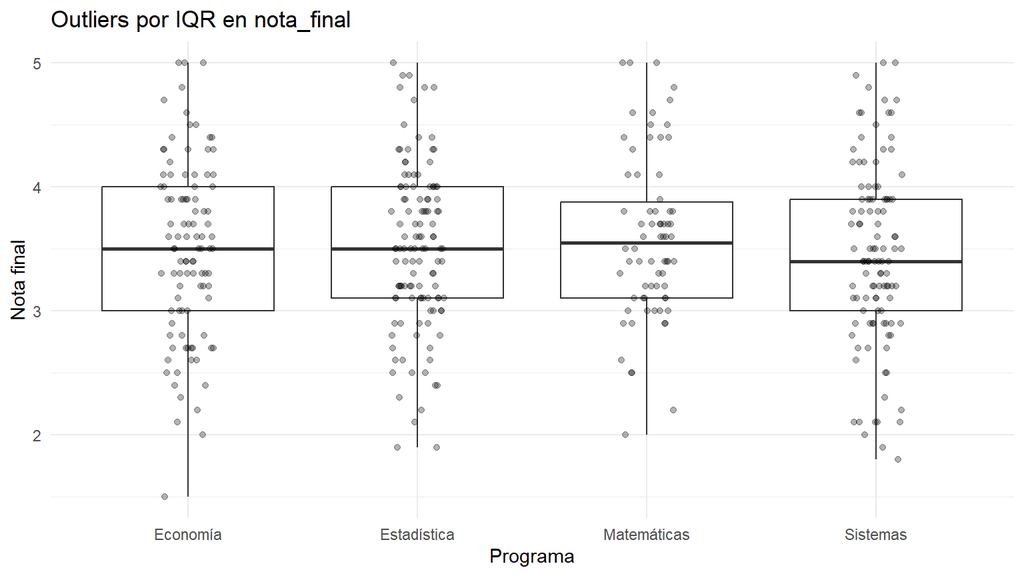

```r
grafico_outliers <- ggplot(
  outliers_estudiantes,
  aes(x = programa, y = nota_final)
) +
  geom_boxplot(outlier.shape = NA) +
  geom_point(
    alpha = 0.30,
    size = 1.4,
    position = position_jitter(width = 0.12, height = 0)
  ) +
  geom_point(
    data = outliers_estudiantes |> filter(outlier_iqr),
    aes(x = programa, y = nota_final),
    color = "red",
    size = 2.2,
    position = position_jitter(width = 0.12, height = 0)
  ) +
  labs(
    title = "Outliers por IQR en nota_final",
    x = "Programa",
    y = "Nota final"
  ) +
  theme_minimal(base_size = 11)

grafico_outliers
```

## 3.1 Comentarios

**1. ¿Coinciden los dos criterios?**

No se hallaron valores atípicos con ninguno de los dos criterios. Por tanto, ambos criterios coinciden en que no detectan outliers en `nota_final` para ninguno de los programas.

**2. ¿Cuándo podría fallar el criterio Z con muestras pequeñas?**

El criterio Z puede fallar cuando la media y la desviación estándar son volátiles. Esto puede ocurrir con muestras pequeñas o con presencia de datos extremos, porque esas observaciones afectan directamente la media y la desviación estándar.

**3 y 4. Visualizar los outliers detectados por IQR sobre un boxplot.**

El gráfico anterior muestra los boxplots por programa. Como no se detectaron valores atípicos por IQR, no aparecen puntos rojos destacados.

**5. ¿Se eliminarían esos puntos del análisis?**

No se hallaron puntos atípicos, por tanto no hay observaciones que eliminar bajo estos criterios. Si aparecieran puntos atípicos, habría que evaluar si aportan información importante sobre el fenómeno o si son errores de registro. Si son datos válidos, sería mejor buscar una vía de modelamiento que permita analizarlos sin penalizar las observaciones usuales.

# 4 Ejercicio 4. Correlación y significancia

```r
correlaciones <- estudiantes |>
  group_by(programa) |>
  summarise(
    r_pearson  = cor(horas_sem, nota_final, method = "pearson"),
    r_spearman = cor(horas_sem, nota_final, method = "spearman"),
    p_pearson  = cor.test(horas_sem, nota_final, method = "pearson")$p.value,
    p_spearman = suppressWarnings(
      cor.test(horas_sem, nota_final, method = "spearman", exact = FALSE)$p.value
    ),
    .groups = "drop"
  ) |>
  mutate(
    pearson_significativo = if_else(p_pearson < 0.05, "Sí", "No"),
    spearman_significativo = if_else(p_spearman < 0.05, "Sí", "No"),
    spearman_mayor = if_else(abs(r_spearman) > abs(r_pearson), "Sí", "No"),
    coinciden_signo = if_else(
      sign(r_pearson) == sign(r_spearman),
      "Sí",
      "No"
    ),
    coinciden_significancia = if_else(
      pearson_significativo == spearman_significativo,
      "Sí",
      "No"
    )
  )

programas_correlacion_significativa <- correlaciones |>
  filter(p_pearson < 0.05 | p_spearman < 0.05)

comparacion_correlaciones <- correlaciones |>
  select(
    programa,
    r_pearson,
    r_spearman,
    pearson_significativo,
    spearman_significativo,
    coinciden_signo,
    coinciden_significancia,
    spearman_mayor
  )

correlaciones
```

```
## # A tibble: 4 × 10
##   programa    r_pearson r_spearman p_pearson p_spearman pearson_significativo
##   <chr>           <dbl>      <dbl>     <dbl>      <dbl> <chr>
## 1 Economía      -0.0204    -0.0417   0.840    0.681     No
## 2 Estadística    0.291      0.352    0.00134  0.0000860 Sí
## 3 Matemáticas    0.334      0.295    0.00472  0.0131    Sí
## 4 Sistemas       0.0614     0.0307   0.522    0.749     No
## # ℹ 4 more variables: spearman_significativo <chr>, spearman_mayor <chr>,
## #   coinciden_signo <chr>, coinciden_significancia <chr>
```

```r
programas_correlacion_significativa
```

```
## # A tibble: 2 × 10
##   programa    r_pearson r_spearman p_pearson p_spearman pearson_significativo
##   <chr>           <dbl>      <dbl>     <dbl>      <dbl> <chr>
## 1 Estadística     0.291      0.352   0.00134  0.0000860 Sí
## 2 Matemáticas     0.334      0.295   0.00472  0.0131    Sí
## # ℹ 4 more variables: spearman_significativo <chr>, spearman_mayor <chr>,
## #   coinciden_signo <chr>, coinciden_significancia <chr>
```

```r
comparacion_correlaciones
```

```
## # A tibble: 4 × 8
##   programa    r_pearson r_spearman pearson_significativo spearman_significativo
##   <chr>           <dbl>      <dbl> <chr>                 <chr>
## 1 Economía      -0.0204    -0.0417 No                    No
## 2 Estadística    0.291      0.352  Sí                    Sí
## 3 Matemáticas    0.334      0.295  Sí                    Sí
## 4 Sistemas       0.0614     0.0307 No                    No
## # ℹ 3 more variables: coinciden_signo <chr>, coinciden_significancia <chr>,
## #   spearman_mayor <chr>
```

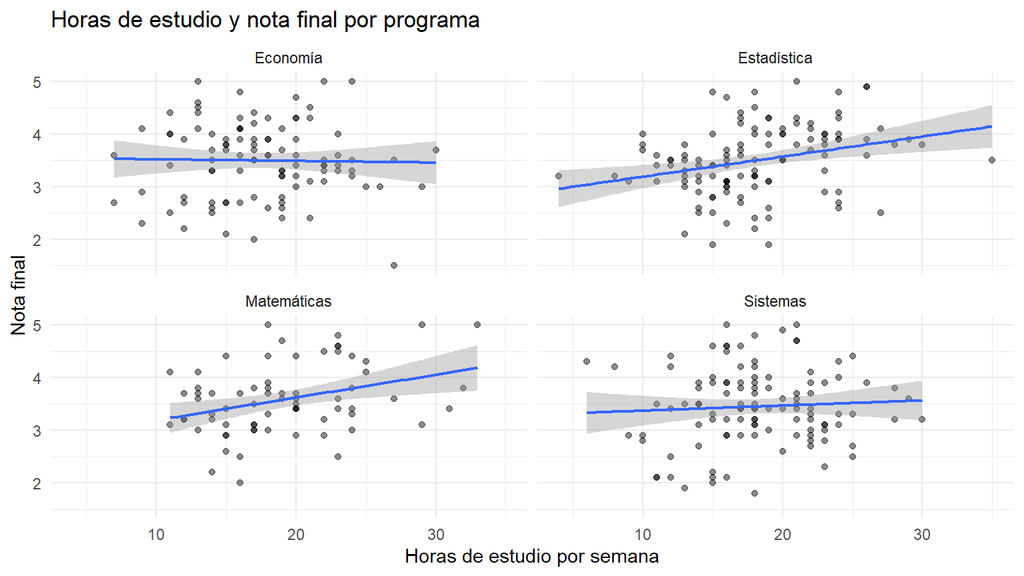

```r
grafico_correlacion <- ggplot(
  estudiantes,
  aes(x = horas_sem, y = nota_final)
) +
  geom_point(alpha = 0.45, size = 1.5) +
  geom_smooth(method = "lm", se = TRUE, linewidth = 0.8) +
  facet_wrap(~ programa) +
  labs(
    title = "Horas de estudio y nota final por programa",
    x = "Horas de estudio por semana",
    y = "Nota final"
  ) +
  theme_minimal(base_size = 11)

grafico_correlacion
```

## 4.1 Comentarios

**1. ¿En qué programas hay correlación significativa?**

Hay correlación significativa en los programas que aparecen en la tabla `programas_correlacion_significativa`.

**2. ¿Pearson y Spearman coinciden?**

La tabla `comparacion_correlaciones` permite revisar si ambos métodos coinciden en signo, significancia y magnitud aproximada.

**3. Si Spearman es mayor que Pearson, ¿qué sugiere?**

Si Spearman supera a Pearson en valor absoluto, puede sugerir presencia de una relación monótona no estrictamente lineal, o influencia de datos extremos sobre Pearson. Spearman es menos sensible a valores lejanos porque trabaja con rangos.

**4 y 5. Graficar dispersograma con `geom_smooth` y `facet_wrap`.**

El gráfico anterior muestra la relación entre horas de estudio y nota final por programa. La tendencia se resume con `geom_smooth(method = "lm")` y la comparación por programa se separa con `facet_wrap()`.

# 5 Ejercicio 5. Comparación de grupos con tamaño del efecto

```r
prueba_kw <- kruskal.test(nota_final ~ programa, data = estudiantes)

H <- as.numeric(prueba_kw$statistic)
p_kw <- prueba_kw$p.value
k <- n_distinct(estudiantes$programa)
n_total <- nrow(estudiantes)

eta2_raw <- (H - k + 1) / (n_total - k)
eta2 <- max(0, eta2_raw)

resultado_kw <- tibble(
  estadistico_H = H,
  p_valor = p_kw,
  eta2_raw = eta2_raw,
  eta2_interpretado = eta2,
  decision = if_else(
    p_kw < 0.05,
    "Se rechaza H0",
    "No se rechaza H0"
  ),
  interpretacion_p_valor = if_else(
    p_kw < 0.05,
    "Hay evidencia de diferencias en nota_final entre programas.",
    "No hay evidencia suficiente de diferencias en nota_final entre programas."
  ),
  tamano_efecto = case_when(
    eta2 < 0.06 ~ "Pequeño",
    eta2 >= 0.06 & eta2 < 0.14 ~ "Mediano",
    eta2 >= 0.14 ~ "Grande"
  )
)

if (p_kw < 0.05) {
  dunn <- FSA::dunnTest(
    nota_final ~ programa,
    data = estudiantes,
    method = "bonferroni"
  )

  resultado_dunn <- dunn$res |>
    as_tibble() |>
    mutate(
      diferencia_significativa = if_else(P.adj < 0.05, "Sí", "No")
    )

  pares_difieren <- resultado_dunn |>
    filter(P.adj < 0.05)

} else {
  dunn <- NULL

  resultado_dunn <- tibble(
    mensaje = "No se aplica Dunn porque Kruskal-Wallis no fue significativo con alpha = 0.05."
  )

  pares_difieren <- tibble(
    mensaje = "No se identifican pares porque no se aplicó prueba post-hoc."
  )
}

prueba_kw
```

```
##
##  Kruskal-Wallis rank sum test
##
## data:  nota_final by programa
## Kruskal-Wallis chi-squared = 1.0944, df = 3, p-value = 0.7784
```

```r
resultado_kw
```

```
## # A tibble: 1 × 7
##   estadistico_H p_valor eta2_raw eta2_interpretado decision
##           <dbl>   <dbl>    <dbl>             <dbl> <chr>
## 1          1.09   0.778 -0.00481                 0 No se rechaza H0
## # ℹ 2 more variables: interpretacion_p_valor <chr>, tamano_efecto <chr>
```

```r
resultado_dunn
```

```
## # A tibble: 1 × 1
##   mensaje
##   <chr>
## 1 No se aplica Dunn porque Kruskal-Wallis no fue significativo con alpha = 0.05.
```

```r
pares_difieren
```

```
## # A tibble: 1 × 1
##   mensaje
##   <chr>
## 1 No se identifican pares porque no se aplicó prueba post-hoc.
```

## 5.1 Comentarios

**1. ¿Se rechaza la hipótesis nula?**

No se rechaza la hipótesis nula.

**2. Interpretar el p-valor en contexto.**

El valor calculado inicialmente de eta-cuadrado puede ser negativo cuando el estadístico $H$ es muy pequeño. Como un tamaño del efecto no se interpreta como negativo, se toma como aproximadamente cero.

Por tanto, el efecto del programa sobre `nota_final` es despreciable. Según los puntos de corte usados, este resultado se clasifica como un tamaño de efecto pequeño, pues está por debajo de 0.06. Su interpretación es coherente con la prueba de Kruskal-Wallis: no hay evidencia suficiente de diferencias entre programas.

**5 y 6. Si hay diferencias, aplicar Dunn con Bonferroni e identificar pares.**

Como Kruskal-Wallis no fue significativo, no se realiza la prueba de Dunn. Tampoco se identifican pares de programas con diferencias significativas.